# Question

You wish to simulate how long your morning commute takes. You break the commute into two parts:

- Moving time
  - Approximately normal with $\mu=15$ minutes and $\sigma=1.9$ minutes.
  - In a spreadsheet, this is simulated with `=norminv(rand(),15,1.9)`
- Waiting time due to 9 intersections.
  - Each intersection has a 0.3 chance to be green. If the light is not green, you will wait up to 4 minutes (following a uniform distribution).
  - In a spreadsheet, **each** intersection is simulated with `=if(rand()<0.3, 0, rand()*4)`

Simulate 1000 repetitions. In each repetition, get the **total** time (moving and waiting). Find the 2.5th percentile and the 97.5th percentile to find the boundaries of the middle 95% of totals. Divide this interval’s width by 2 to get the margin of error.

What is your simulated **margin of error**?

# Solution

You should get a margin of error near 8.57 minutes. The tolerance should take anything from 7.69 and 9.45 minutes.

I’ve shown a histogram of my simulation below.

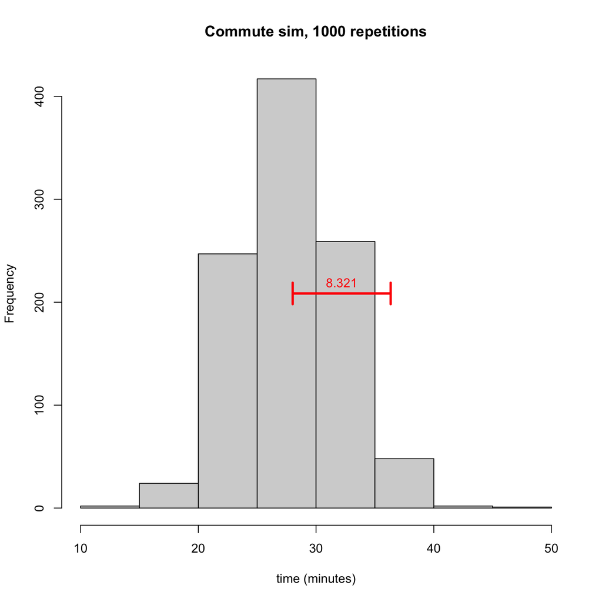

- In a spreadsheet, put `=norminv(rand(),15,1.9)` in cells A1:A1000.
- Put `=if(rand()<0.3, 0, rand()*4)` in cells B1:J1000.
- In cell L1, put `=sum(A1:J1)`. Drag formula down to cell L1000.
- Freeze the simulation by copying everything and pasting **values only**.
- Sort sheet by column L.
- Find the values at L25 and L975. These are the boundaries of the interval of typical totals.
- Subtract those boundaries and divide the result by 2 to find the margin of error.

# Meta-information

extype: num exsolution: 8.57 exname: stoplight_sim extol: 0.88